# benthos-trends-dataprep

Tom Webb 2023-03-06

## Temporal trends from presence-absence data in European benthos

This document desrcibes the workflow for assembling the data sets required to produce spatial estimates of temporal turnover (species loss and gain, beta diversity) from the EMODnet macrobenthos presence-absence product.

First, load required packages:

```r
library(tidyverse)
library(ncdf4)
library(here)
library(worrms)
```

The main presence-absence dataset is provided as a NetCDF file. This will be served via EMODnet but is accessed locally here. First, establish a connection to the file:

```r
nc_fil <- nc_open(here("data", "raw_data/Macrobenthos_Eur_Seas_Pres_Abs_v0-4.nc"))
```

### Assembling a data set of unique sampling events

Assemble a data frame of sampling events, composed of latitude, longitude, full date, and year from the .nc file:

```r
sample_events <- tibble(
  lat = as.vector(ncvar_get(nc_fil, "lat")),
  lon = as.vector(ncvar_get(nc_fil,"lon")),
  date = lubridate::ymd(as.Date(ncvar_get(nc_fil, "Date"), origin = "1970-01-01 00:00:00")),
  year = lubridate::year(as.Date(ncvar_get(nc_fil, "Date"), origin = "1970-01-01 00:00:00"))
)
```

Note that there are fewer distinct sampling events (289634) than there are total sampling events (292332). Note also that a few sampling events have dates in the future:

```
## # A tibble: 4 × 4
##     lat   lon date        year
##   <dbl> <dbl> <date>     <dbl>
## 1  53.3 -3.17 2035-05-19  2035
## 2  51.6 -4.89 2032-05-25  2032
## 3  59.1 -5.83 2030-08-10  2030
## 4  59.1 -5.81 2028-09-29  2028
```

### Assembling a dataset of unique species IDs

First get all taxon names and WoRMS Aphia IDs from the nc file:

```r
taxon_name <- ncvar_get(nc_fil, "Taxon_Name")
aphia_id <- ncvar_get(nc_fil,"AphiaID") %>% word(start = -1, sep = ":") %>% as.integer()
```

For this product, we use only taxa at the species rank only. To do this this we need to get the WoRMS classification for each taxon, and take the final entry in this. For this we use a simple function:

```r
get_worms_rank <- function(aphiaid){
  classif <- wm_classification(aphiaid) %>% slice(n())
  classif
}
```

To run for one taxon:

```r
get_worms_rank(aphia_id[1000])
```

```
## # A tibble: 1 × 3
##   AphiaID rank    scientificname
##     <int> <chr>   <chr>
## 1  855675 Species Cylista undata
```

This will run the function over all taxa. *WARNING*: this takes ~40 minutes on my machine:

```r
taxo <- aphia_id %>% map_df(get_worms_rank, .progress = TRUE)
```

Because this is slow to run, the output was written to file (`write_csv(taxo, file = here("data", "EMODnet-Biology-Benthos-European-Seas/benthos_taxo_rank.csv"))`), so it can simply be read in directly here:

```r
taxo <- read_csv(here("data", "derived_data/benthos_taxo_rank.csv"))
```

What ranks are present?

```r
taxo %>% count(rank) %>% arrange(desc(n)) %>% print(n = 100)
```

```
## # A tibble: 23 × 2
##    rank             n
##    <chr>        <int>
##  1 Species       8149
##  2 Genus         1679
##  3 Family         529
##  4 Order           89
##  5 Subspecies      83
##  6 Subfamily       64
##  7 Superfamily     62
##  8 Class           36
##  9 Suborder        32
## 10 Subclass        20
## 11 Phylum          17
## 12 Subgenus        16
## 13 Infraorder      13
## 14 Subphylum        8
## 15 Superorder       8
## 16 Kingdom          7
## 17 Infraclass       6
## 18 Tribe            5
## 19 Superclass       2
## 20 Infrakingdom     1
## 21 Parvorder        1
## 22 Subterclass      1
## 23 Variety          1
```

To get a list of only species-rank taxa (adding an index for ease of matching later):

```r
spp <- taxo %>%
  filter(rank == "Species") %>%
  mutate(aphia_index = match(.$AphiaID, taxo$AphiaID))
```

This results in 8149 unique species-level benthic taxa.

### Get occurrences of a species by sampling event

We can get presence-absence for a single species directly from the nc file:

```r
presabs <- ncvar_get(nc_fil,"Pres_abs",
                     start = c(1, spp$aphia_index[1]), count = c(-1,1))
```

To run this across species, wrap it in a function:

```r
get_presabs_sp <- function(sp_index, sp_df = spp, samps = sample_events){

  # get pres-abs data
  presabs <- ncvar_get(nc_fil, "Pres_abs",
                       start = c(1, sp_index), count = c(-1,1))
  # assemble data frame
  ret <- tibble(aphia_id = spp$AphiaID[spp$aphia_index == sp_index],
                presabs = presabs)
  ret <- samps %>% bind_cols(ret)

  ret
}
```

Run this for a single species and get a count of presences and absences:

```r
presabs <- get_presabs_sp(sp_index = spp$aphia_index[1])
presabs %>% count(presabs)
```

```
## # A tibble: 3 × 2
##     presabs      n
##   <int[1d]>  <int>
## 1         0 230910
## 2         1  33777
## 3        NA  27645
```

NB: 1 = Present, 0 = looked for but absent, NA = not looked for. A value of ‘NA’ indicates that at that sampling event, only a subset of the full benthos community was effectively surveyed. To work out how big an issue this is, we can get species-level summaries of numbers of presences, absences, and NAs, in a function:

```r
get_presabs_sp_summ <- function(sp_index, sp_df = spp){

  # get pres-abs data
  presabs <- ncvar_get(nc_fil, "Pres_abs",
                       start = c(1, sp_index), count = c(-1,1))
  # assemble data frame
    ret <- tibble(presabs = presabs) %>%
      count(presabs) %>%
      mutate(aphia_id = spp$AphiaID[spp$aphia_index == sp_index]) %>%
      dplyr::select(aphia_id, everything())

  ret
}
```

What this does for a single species:

```r
get_presabs_sp_summ(sp_index = spp$aphia_index[1])
```

```
## # A tibble: 3 × 3
##   aphia_id   presabs      n
##      <dbl> <int[1d]>  <int>
## 1   141579         0 230910
## 2   141579         1  33777
## 3   141579        NA  27645
```

Run across species and summarise (takes a minute or two to run):

```r
pres_abs_summ <- spp %>% pull(aphia_index) %>%
  purrr::map(get_presabs_sp_summ, .progress = TRUE) %>%
  bind_rows()

pres_abs_summ %>% group_by(presabs) %>% summarise(n_cases = sum(n))
```

```
## # A tibble: 3 × 2
##     presabs    n_cases
##   <int[1d]>      <int>
## 1         0 1989927446
## 2         1    3314018
## 3        NA  388972004
```

So there is a manageable number of presences (~3.3M) but the number of absences (~2bn) and NAs (~389M) will cause issues.

Given that NA indicates an incomplete survey of the benthic community, the decision taken for this product is not to consider sampling events that include NA for any species. First, add a new variable to `sample_events`, `includes_na`, setting this to be `FALSE` for all sampling events initially:

```r
sample_events <- sample_events %>% mutate(includes_na = FALSE)
```

This function finds for a given species which (if any) sampling events include NA, and changes the `includes_na` flag to `TRUE` for any events that do:

```r
get_na_events <- function(sp_index, samps = sample_events){

  # get pres-abs data
  presabs <- ncvar_get(nc_fil, "Pres_abs",
                       start = c(1, sp_index), count = c(-1,1))
  # flag NAs in sample_events
  samps <- samps %>% mutate(includes_na = ifelse(is.na(presabs), TRUE, includes_na))
  samps
}
```

Then run this over all species, saving the results to a new object called `na_events` (takes a couple of minutes):

```r
na_events <- sample_events
for(i in spp$aphia_index){
  na_events <- get_na_events(sp_index = i, samps = na_events)
}
```

What are the consequences of this?

```r
na_events %>% count(includes_na)
```

```
## # A tibble: 2 × 2
##   includes_na      n
##   <lgl[1d]>    <int>
## 1 FALSE       243848
## 2 TRUE         48484
```

So getting rid of these would remove 16.6% of all sample events. Are these biased in time?

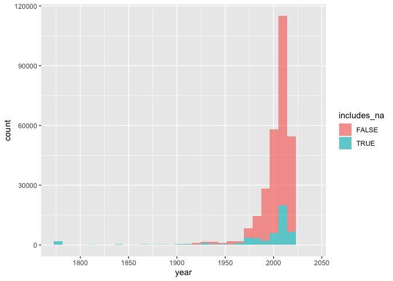

Not obviously - although we may lose some of the much older events.

### Final assembly of `sample_events`

To finalise `sample_events`, re-create it from `na_events`, add an id variable from the rownumber, and deal with the dates in the future (here simply by flagging them in the `includes_na` variable so they can be filtered out easily in one step):

```r
sample_events <- na_events %>%
  mutate(sample_id = row_number()) %>%
  dplyr::select(sample_id, everything()) %>%
  mutate(includes_na = ifelse(date > lubridate::now(), TRUE, includes_na))
```

This can then be written to file `(write_csv(sample_events, file = here("data", "derived_data/sample_events.csv"))` allowing the final assembled version of `sample_events` to be read in quickly here:

```r
sample_events <- read_csv(here("data",
                               "derived_data/sample_events.csv"))
```

### Assemble species presence x site data frame

This assembles the long species presence x site df, for non-na sites only. It uses a revised version of the previous `get_presabs_sp()` function which excludes NA sites:

```r
get_presabs_sp_na_rm <- function(sp_index, sp_df = spp, samps = sample_events){

  # get pres-abs data
  presabs <- ncvar_get(nc_fil, "Pres_abs",
                       start = c(1, sp_index), count = c(-1,1))
  # assemble data frame
  ret <- tibble(aphia_id = spp$AphiaID[spp$aphia_index == sp_index],
                presabs = presabs)
  ret <- samps %>% bind_cols(ret)

  # filter to presences and non-NA sites
  ret <- ret %>% filter(presabs == 1 & includes_na == FALSE) %>%
    dplyr::select(sample_id, aphia_id)

  ret
}
```

Run for one species - this needs the `spp` table of species:

```r
taxo <- read_csv(here("data", "derived_data/benthos_taxo_rank.csv"))
spp <- taxo %>%
  filter(rank == "Species") %>%
  mutate(aphia_index = match(.$AphiaID, taxo$AphiaID))
```

Then run the presence-absence function for a single species:

```r
get_presabs_sp_na_rm(sp_index = spp$aphia_index[1])
```

```
## # A tibble: 31,099 × 2
##    sample_id aphia_id
##        <dbl>    <dbl>
##  1       212   141579
##  2       266   141579
##  3       302   141579
##  4      2728   141579
##  5      2729   141579
##  6      2739   141579
##  7      2743   141579
##  8      2831   141579
##  9      3431   141579
## 10      4143   141579
## # … with 31,089 more rows
```

Now run over all species to generate a full dataframe of species presence at each site (excluding sites with NA values) - this takes around 5 minutes:

```r
pres_df <- spp %>% pull(aphia_index) %>%
  purrr::map(get_presabs_sp_na_rm, .progress = TRUE) %>%
  bind_rows()
```

From this we can get (and plot) e.g. a summary of species occurrence frequencies:

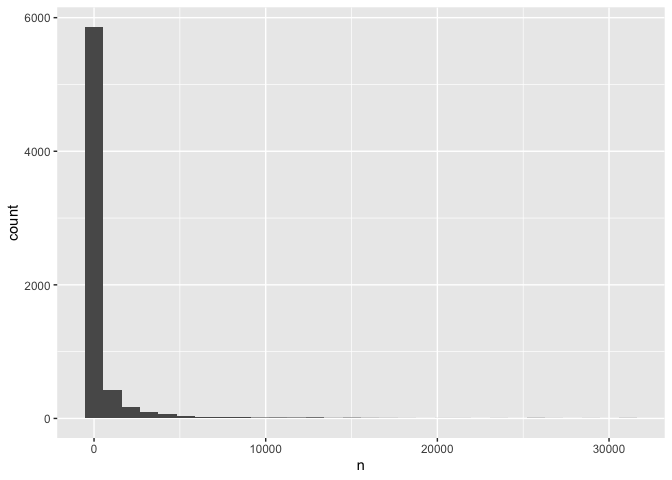

```r
sp_occ_summary <- pres_df %>% count(aphia_id) %>% arrange(n)
ggplot(sp_occ_summary) + geom_histogram(aes(x = n))
```

So for instance 1064 species occur in only a single sample; 5706 occur in more than one.

Before closing the nc connection, first extract the Coordinate Reference System:

```r
presabs_crs <- ncatt_get(nc_fil, "crs")
```

Also worth saving the presence data (`pres_df`) to file for direct loading (`write_csv(pres_df, file = here("data", "derived_data/pres_df.csv"))`) allowing the final presence data frame to be read in quickly here:

```r
pres_df <- read_csv(here("data",
                         "derived_data/pres_df.csv"))
```

Finally close the nc connection:

```r
nc_close(nc_fil)
```

The two derived datasets, `sample_events.csv` and `pres_df.csv` are now available in the `data/derived_data` folder for use in calculating temporal turnove metrics as described in `documents/benthos-trends-turnover`.

### Reproducibility

**Reproducibility receipt**

Date of rendering:

```
## [1] "2023-03-16 21:29:06 GMT"
```

Repository: https://github.com/EMODnet/benthos-trends